# Aflevering 9

Lucas Bagge

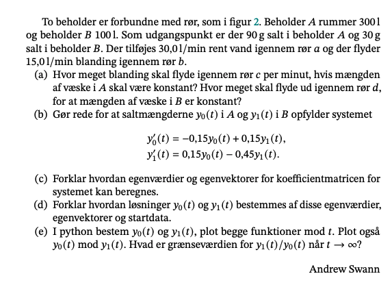

## a) Definer

I den første del af opgaven skal vi komme frem til hvor meget der kan flyde igennem rør c per minut og det samme for rør d således at mængden af væske i respektiv A og B er konstant.

## b)

For opgave b skal vi gøre rede for at saltmængderne i A og B kan opskrives gennem følgende system:

$$y_0'(t)=\underbrace{-0.15 y_0 (t)}_\textrm{a} + \underbrace{0.15 y_1 (t)}_\textrm{b}$$

$$y_1'(t)=\underbrace{0.15 y_0 (t)}_\textrm{c} - \underbrace{0.45 y_1 (t)}_\textrm{d}$$
Her kan vi løse følgende (da vi kender hvad der skal være i hver beholder)

$$\frac{a \ l/min}{300 \ l }= 0.15 \ l$$

$$a = 300 * 0.15 = -45$$

a svarer til hvad beholder A mister af salt per minut.

Vi kan bekræfte at b skal være 0.15 ved at kigge på oplysning fra opgaven da vi kan se at der tilføjes $15(t_1(t)/100)$ gram salt per minut. Derfor kan vi sige at det første system er opfyldt med ovenstående ligning.

Den samme øvelse kan vi gøre med $y'_1(t)$.

$$\frac{c \ l/min}{300} = 0.15$$
$$c = 45$$

Således passer det med at der skal forlade 45 l/min fra c. Når det passer vil vi have at beholder B modtager $0.15 y_0(t)$ gram salt per minut.

For at beregne d så skal vi kombiner de to strømme hvor beholder B mister væske fra, nemlig b og d. Vi kender b = 15 l/min, mens vi ikke kender d.

$$\frac{15 + d}{100} = 0.45$$

$$15+d=45$$

$$d = 30$$

Altså vil det sige at der flyder 30 l/min salt ud af rør d.

Når det gælder så vil saltmængderne i $y_0$ og $y_1$ være opfyldt.

## c)

Her skal vi forklare hvordan egenværdier og egenvektorer for koefficientmatricen kan beregnes.

Vi kan starte med at opskrive systemet op i vektor notation som er vist ved ligning 22.2 i note sættet:

$$A = \begin{bmatrix}
-0.15 & 0.15 \\
0.15 & -0.45
\end{bmatrix}$$

Hvor begyndelseværdier er angivet ved mængden af salt:

$$y(0)=
\begin{bmatrix}
90 \\
30
\end{bmatrix}$$
Egenværiderne og egenvektor kan beregnes ved at regne det karakteristik polynomium og herved check om A er diagonaliserbar.

opskriv det karakteristik polynomium

$$det =
\begin{bmatrix}
-0.15 - \lambda & 0.15 \\
0.15 & -0.45-\lambda
\end{bmatrix}
= \lambda^2+0.6\lambda+0.045$$
Som har rødderne:

$$\frac{-0.6+-\sqrt{0.6^2-4*1*0.045}}{2*1}$$
$$\text{med egenværdierne; } \ -0.512, \ -0.089$$

Matricen er en 2 x 2 matrix og vi har to forskellig rødde så A er diagonaliserbar.

Hvorefter vi kan beregne egenvektor for hver egenværdier. Her benytter jeg mig af et cas værkstøj til disse udregninger.

Her får jeg en egenvektor til $v_0=(2.41,1)$ og $v_1=(-0.4142,1)$

Hermed har jeg udfra det karakteristiske polynomium og det faktum at A er diagonaliserbar fundet frem til egenværdierne og egenvektorerne.

## d)

Her skal vi nu bestemme en løsning.

Løsnigen kan beregnes ved at opsætte et ligning system som følger proposition 22.2.

Den manuelle beregning vil jeg foretage her og i opgave e skal de regnes i python.

For en løsning benytter vi os af proposition 22.2:

$$y(t) = c_0 \begin{bmatrix} 2.41 \\ 1\end{bmatrix}e^{-0.512 t} +c_1
\begin{bmatrix} -0.4141 \\ 1\end{bmatrix}e^{-0.089 t}$$
Her kan vi bestemme konstanterne c0 go c1 ud fra begyndelsesdata. Ved t =0 har vi

$$y(0)=c_0 \begin{bmatrix} 2.41\\ 1\end{bmatrix}+c_1 \begin{bmatrix} -0.4141\\1 \end{bmatrix}=\begin{bmatrix} 90\\30\end{bmatrix}$$

## e)

De sidste par trin i d skal jeg også gøre i python og derved bestemme $y_0(t)$ og $y_1(t)$.

```python
import numpy as np

A = np.array([
  [2.41, -0.41],
  [1, 1]])

B = np.array([
  [90],
  [30]])

np.linalg.inv(A).dot(B)
```

```
## array([[36.27659574],
##        [-6.27659574]])
```

Som er vores løsnign som jeg også løste til slut i d.

Skrevet på formel har vi

y(t)=
$$\begin{bmatrix} y_0(t)\\y_1(t)\end{bmatrix}$$
= 36.27
$$\begin{bmatrix} 2.41\\1 \end{bmatrix}$$

[figure not shown]

```python
#import matplotlib.pyplot as plt
import numpy as np
v0 = np.array([2.41, 1.0])[:, np.newaxis]
v1 = np.array([-0.41, 1.0])[:, np.newaxis]
lambda0 = -0.512
lambda1 = -0.089
t = np.linspace(0, 100, 100)
løsning = (36.27 * v0 * np.exp(lambda0 * t) - 6.27 * v1 * np.exp(lambda1 * t))

#fig, ax = plt.subplots()
#ax.set_aspect('equal')
#ax.plot(*løsning,marker='o', markevery=10, markersize=4)
#plt.show()
```

Som er vores plot af løsningen.